# Modellierung des Weihnachtsgeschenkbudgets

Vincent Schmalor, Hendrick Kaiser, Lukas Küppers

3.1.2020

```r
knitr::opts_chunk$set(echo = TRUE)
library(mosaic)
library(corrplot)
library(kableExtra)
library(reshape2)
source("http://www.sthda.com/upload/rquery_cormat.r")
#Funktion zum Löschen aller Ausreißer, die nach IQR-1.5 Methode als Ausreißer gelten
remove_outliers <- function(x, na.rm = TRUE, ...) {
  qnt <- quantile(x, probs=c(.25, .75), na.rm = na.rm, ...) # Vektor mit Quartilen 25% und 75% erstellen
  H <- 1.3 * IQR(x, na.rm = na.rm) #Antennenberechnung
  y <- x
  y[x < (qnt[1] - H)] <- NA #Untere Ausreißer entfernen
  y[x > (qnt[2] + H)] <- NA #Obere Ausreißer
  y
}

#Funktion für die Darstellung der Favstats für jede Spalte
multi.fun <- function(x) {
      c(min = min(x), mean = mean(x), max = max(x), sd = sd(x), q1 = quantile(x, 0.25), med = median(x), q3 = quantile(x,0.75))
}
raw.training <- read.csv2("sources/Trainingsdaten.csv")
```

# Einleitung

Dieses Dokument stellt sowohl die Durchführung, als auch die Protokollierung des Vorhersagewettbewerbs dar. Die Aufgabenstellung besteht darin, ein Modell aus einem Grunddatensatz zu entwickeln und dieses Modell auf einen Anwendungsdatensatz anzuwenden. Dabei wird aus mehreren Einflussvariablen eine abhängige Variable geschätzt. Der konkrete Anwendungsfall ist ein Auszug aus einem Face-to-Face Interview über das Konsum- und Schenkverhalten zu Weihnachten. Das Grunddatenset beinhaltet 400 Beobachtungen mit 17 erklärenden Variablen und die abhängige Variable des geschätzten Budgets, die es im Anwendungsdatenset zu modellieren gilt. In dem folgenden Kapitel wird diese Aufgabe bearbeitet, indem zunächst ein Überblick über die Daten in einer explorativen Datenanalyse gegeben wird. Anhand verschiedener Analysen und der Untersuchung der semantischen Zusammenhänge wird dann eine Vorgehensweise erarbeitet und beschrieben. Das Ergebnis ist eine csv-Datei, die das Anwendungsdatenset mit der modellierten, abhängigen Variable beinhaltet. So wird eine Prognose über diese Variable für jede Beobachtung gegeben, für die das tatsächliche Budget nicht vorliegt. Eine Zusammenfassung der Ergebnisse findet sich auch auf dem Plakat der genannten Autoren.

# Explorative Datenanalyse

## Rohdatenanalyse und -strukturierung

Kurzer Überblick über die vorhandenen Daten in ihrer Rohform.

```r
#Visualisierung der Rohdaten in schönen Tabellen
kable(head(raw.training, n= 10)) %>%
  kable_styling(bootstrap_options = c("striped", "hover"))
```

| X7.1 | X7.2 | X7.3 | X7.4 | X7.5 | X7.6 | X7.7 | X9.1 | X9.2 | X9.3 | X9.4 | X9.5 | X9.6 | X9.7 | X9.8 | D1 | D2 | X10.1 |
| --- | --- | --- | --- | --- | --- | --- | --- | --- | --- | --- | --- | --- | --- | --- | --- | --- | --- |
| 5 | 5 | 5 | 1 | 5 | 3 | 2 | 1 | 1 | 1 | 0 | 0 | 0 | 0 | 0 | 27 | 1 | 300 |
| 3 | 1 | 1 | 1 | 1 | 3 | 1 | 0 | 1 | 1 | 0 | 0 | 1 | 0 | 0 | 18 | 2 | 150 |
| 1 | 7 | 7 | 1 | 1 | 1 | 1 | 1 | 0 | 0 | 0 | 0 | 1 | 0 | 0 | 25 | 1 | 50 |
| 5 | 5 | 5 | 1 | 1 | 5 | 2 | 0 | 1 | 1 | 0 | 1 | 0 | 0 | 0 | 36 | 2 | 50 |
| 6 | 7 | 7 | 3 | 2 | 4 | 5 | 1 | 1 | 0 | 0 | 0 | 0 | 0 | 0 | 30 | 1 | 100 |
| 5 | 1 | 5 | 4 | 6 | 6 | 4 | 1 | 1 | 1 | 0 | 0 | 1 | 0 | 0 | 51 | 1 | 1000 |
| 7 | 7 | 7 | 7 | 5 | 6 | 7 | 1 | 1 | 1 | 0 | 1 | 0 | 0 | 0 | 56 | 2 | 700 |
| 7 | 1 | 7 | 7 | 2 | 4 | 7 | 1 | 0 | 0 | 0 | 1 | 1 | 0 | 1 | 57 | 2 | 600 |
| 4 | 7 | 2 | 3 | 1 | 4 | 7 | 0 | 0 | 1 | 0 | 1 | 0 | 0 | 0 | 70 | 1 | 500 |
| 1 | 1 | 7 | 1 | 1 | 6 | 6 | 1 | 1 | 1 | 0 | 0 | 1 | 0 | 0 | 38 | 2 | 400 |

```r
kable(apply(raw.training, 2, multi.fun)) %>%
  kable_styling(bootstrap_options = c("striped", "hover"))
```

|  | X7.1 | X7.2 | X7.3 | X7.4 | X7.5 | X7.6 | X7.7 | X9.1 | X9.2 | X9.3 | X9.4 | X9.5 | X9.6 | X9.7 | X9.8 | D1 | D2 | X10.1 |
| --- | --- | --- | --- | --- | --- | --- | --- | --- | --- | --- | --- | --- | --- | --- | --- | --- | --- | --- |
| min | 1.000000 | 1.000000 | 1.000000 | 1.000000 | 1.000000 | 1.000000 | 1.000000 | 0.0000000 | 0.0000000 | 0.0000000 | 0.0000000 | 0.0000000 | 0.0000000 | 0.0000000 | 0.0000000 | 18.00000 | 1.0000000 | 1.0000 |
| mean | 5.145000 | 4.515000 | 4.680000 | 3.585000 | 3.635000 | 4.417500 | 3.862500 | 0.7425000 | 0.6250000 | 0.6300000 | 0.0200000 | 0.5800000 | 0.4675000 | 0.1175000 | 0.0625000 | 47.45750 | 1.4825000 | 486.6900 |
| max | 7.000000 | 7.000000 | 7.000000 | 7.000000 | 7.000000 | 7.000000 | 7.000000 | 1.0000000 | 1.0000000 | 1.0000000 | 1.0000000 | 1.0000000 | 1.0000000 | 1.0000000 | 1.0000000 | 88.00000 | 2.0000000 | 3500.0000 |
| sd | 1.872897 | 1.953026 | 2.099672 | 2.039159 | 1.915973 | 1.859257 | 2.010896 | 0.4378047 | 0.4847292 | 0.4834089 | 0.1401753 | 0.4941766 | 0.4995675 | 0.3224184 | 0.2423646 | 18.67901 | 0.5003194 | 427.1325 |
| q1.25% | 4.000000 | 3.000000 | 3.000000 | 2.000000 | 2.000000 | 3.000000 | 2.000000 | 0.0000000 | 0.0000000 | 0.0000000 | 0.0000000 | 0.0000000 | 0.0000000 | 0.0000000 | 0.0000000 | 31.00000 | 1.0000000 | 200.0000 |
| med | 6.000000 | 5.000000 | 5.000000 | 4.000000 | 4.000000 | 5.000000 | 4.000000 | 1.0000000 | 1.0000000 | 1.0000000 | 0.0000000 | 1.0000000 | 0.0000000 | 0.0000000 | 0.0000000 | 47.50000 | 1.0000000 | 400.0000 |
| q3.75% | 7.000000 | 6.000000 | 7.000000 | 5.000000 | 5.000000 | 6.000000 | 6.000000 | 1.0000000 | 1.0000000 | 1.0000000 | 0.0000000 | 1.0000000 | 1.0000000 | 0.0000000 | 0.0000000 | 61.00000 | 2.0000000 | 600.0000 |

Kurzer Überblick über die Daten mit richtigen Spaltenbeschriftungen, um sie interpretieren zu können

```r
#Auswahl der Spalten, die als Faktor interpretiert werden sollen. Nicht ausgeführt, um Regressionsanalysen durchführen zu können
# cols <- c("X7.1","X7.2","X7.3","X7.4","X7.5","X7.6","X7.7","X9.1","X9.2","X9.3","X9.4","X9.5","X9.6","X9.7","X9.8","D2")
#raw.training[cols] <- lapply(raw.training[cols], factor) #Faktorspalten setzen
#Spalten mit sprechenden Überschriften versehen
colnames(raw.training) <- c("Beratung", "Angebote","Bequemlichkeit","Einkaufsatmosphaere","Marken","GPM","Naehe","Partner","Eltern","Verwandte","Kommilitonen","Kinder","Freunde","Arbeitskollegen","Soziale.Institutionen","Alter","Geschlecht","Budget")
kable(head(raw.training, n= 10)) %>%
  kable_styling(bootstrap_options = c("striped", "hover")) #Dataset erneut anschauen
```

| Beratung | Angebote | Bequemlichkeit | Einkaufsatmosphaere | Marken | GPM | Naehe | Partner | Eltern | Verwandte | Kommilitonen | Kinder | Freunde | Arbeitskollegen | Soziale.Institutionen | Alter | Geschlecht | Budget |
| --- | --- | --- | --- | --- | --- | --- | --- | --- | --- | --- | --- | --- | --- | --- | --- | --- | --- |
| 5 | 5 | 5 | 1 | 5 | 3 | 2 | 1 | 1 | 1 | 0 | 0 | 0 | 0 | 0 | 27 | 1 | 300 |
| 3 | 1 | 1 | 1 | 1 | 3 | 1 | 0 | 1 | 1 | 0 | 0 | 1 | 0 | 0 | 18 | 2 | 150 |
| 1 | 7 | 7 | 1 | 1 | 1 | 1 | 1 | 0 | 0 | 0 | 0 | 1 | 0 | 0 | 25 | 1 | 50 |
| 5 | 5 | 5 | 1 | 1 | 5 | 2 | 0 | 1 | 1 | 0 | 1 | 0 | 0 | 0 | 36 | 2 | 50 |
| 6 | 7 | 7 | 3 | 2 | 4 | 5 | 1 | 1 | 0 | 0 | 0 | 0 | 0 | 0 | 30 | 1 | 100 |
| 5 | 1 | 5 | 4 | 6 | 6 | 4 | 1 | 1 | 1 | 0 | 0 | 1 | 0 | 0 | 51 | 1 | 1000 |
| 7 | 7 | 7 | 7 | 5 | 6 | 7 | 1 | 1 | 1 | 0 | 1 | 0 | 0 | 0 | 56 | 2 | 700 |
| 7 | 1 | 7 | 7 | 2 | 4 | 7 | 1 | 0 | 0 | 0 | 1 | 1 | 0 | 1 | 57 | 2 | 600 |
| 4 | 7 | 2 | 3 | 1 | 4 | 7 | 0 | 0 | 1 | 0 | 1 | 0 | 0 | 0 | 70 | 1 | 500 |
| 1 | 1 | 7 | 1 | 1 | 6 | 6 | 1 | 1 | 1 | 0 | 0 | 1 | 0 | 0 | 38 | 2 | 400 |

```r
kable(apply(raw.training, 2, multi.fun)) %>%
  kable_styling(bootstrap_options = c("striped", "hover"))
```

|  | Beratung | Angebote | Bequemlichkeit | Einkaufsatmosphaere | Marken | GPM | Naehe | Partner | Eltern | Verwandte | Kommilitonen | Kinder | Freunde | Arbeitskollegen | Soziale.Institutionen | Alter | Geschlecht | Budget |
| --- | --- | --- | --- | --- | --- | --- | --- | --- | --- | --- | --- | --- | --- | --- | --- | --- | --- | --- |
| min | 1.000000 | 1.000000 | 1.000000 | 1.000000 | 1.000000 | 1.000000 | 1.000000 | 0.0000000 | 0.0000000 | 0.0000000 | 0.0000000 | 0.0000000 | 0.0000000 | 0.0000000 | 0.0000000 | 18.00000 | 1.0000000 | 1.0000 |
| mean | 5.145000 | 4.515000 | 4.680000 | 3.585000 | 3.635000 | 4.417500 | 3.862500 | 0.7425000 | 0.6250000 | 0.6300000 | 0.0200000 | 0.5800000 | 0.4675000 | 0.1175000 | 0.0625000 | 47.45750 | 1.4825000 | 486.6900 |
| max | 7.000000 | 7.000000 | 7.000000 | 7.000000 | 7.000000 | 7.000000 | 7.000000 | 1.0000000 | 1.0000000 | 1.0000000 | 1.0000000 | 1.0000000 | 1.0000000 | 1.0000000 | 1.0000000 | 88.00000 | 2.0000000 | 3500.0000 |
| sd | 1.872897 | 1.953026 | 2.099672 | 2.039159 | 1.915973 | 1.859257 | 2.010896 | 0.4378047 | 0.4847292 | 0.4834089 | 0.1401753 | 0.4941766 | 0.4995675 | 0.3224184 | 0.2423646 | 18.67901 | 0.5003194 | 427.1325 |
| q1.25% | 4.000000 | 3.000000 | 3.000000 | 2.000000 | 2.000000 | 3.000000 | 2.000000 | 0.0000000 | 0.0000000 | 0.0000000 | 0.0000000 | 0.0000000 | 0.0000000 | 0.0000000 | 0.0000000 | 31.00000 | 1.0000000 | 200.0000 |
| med | 6.000000 | 5.000000 | 5.000000 | 4.000000 | 4.000000 | 5.000000 | 4.000000 | 1.0000000 | 1.0000000 | 1.0000000 | 0.0000000 | 1.0000000 | 0.0000000 | 0.0000000 | 0.0000000 | 47.50000 | 1.0000000 | 400.0000 |
| q3.75% | 7.000000 | 6.000000 | 7.000000 | 5.000000 | 5.000000 | 6.000000 | 6.000000 | 1.0000000 | 1.0000000 | 1.0000000 | 0.0000000 | 1.0000000 | 1.0000000 | 0.0000000 | 0.0000000 | 61.00000 | 2.0000000 | 600.0000 |

## Erweiterung um abgeleitete Metriken

Fügt die folgenden Metriken hinzu: - Anzahl der bedachten Gruppen

```r
#Anzahl der bedachten Personen als zusätzliche Spalte hinzufügen
raw.training <- raw.training %>% mutate(gift.count = (Partner*1) + (Eltern*1) +(Verwandte*1) + (Kommilitonen*1) + (Kinder*1) + (Freunde*1) + (Arbeitskollegen*1) + (Soziale.Institutionen*1))
```

```r
#Anzahl der bedachten Personen als zusätzliche Spalte hinzufügen
raw.training <- raw.training %>% mutate(wertschaetzung = Beratung + Bequemlichkeit + Einkaufsatmosphaere + Marken)
```

```r
#Test mit gewichteten Gruppen war nicht erfolgreich
#raw.training <- raw.training %>% mutate(gift.count = (X9.1*2.5) + (X9.2*2) + (X9.3*2) + (X9.4*0.5) + (X9.5*1) + (X9.6*1.5) + (X9.7*0.75) + (X9.8*0.5))
```

## Bereinigung der Datenmenge von Ausreißern

Ausreißer identifizieren und bereinigtes Dataset in “training” speichern.

```r
col.Budget <- pull(raw.training, Budget) #Spalte extrahieren, um Ausreißer zu identifizieren
training <- raw.training %>% mutate("cleaned.Budget" = remove_outliers(col.Budget)) #Ausreißer nullen und in neues Datenset speichern
training <- training %>% filter(!is.na(cleaned.Budget)) #Datenset um Ausreißer bereinigen
training <- subset(training, select = -(cleaned.Budget))
kable(head(training, n= 10)) %>%
  kable_styling(bootstrap_options = c("striped", "hover"))
```

| Beratung | Angebote | Bequemlichkeit | Einkaufsatmosphaere | Marken | GPM | Naehe | Partner | Eltern | Verwandte | Kommilitonen | Kinder | Freunde | Arbeitskollegen | Soziale.Institutionen | Alter | Geschlecht | Budget | gift.count | wertschaetzung |
| --- | --- | --- | --- | --- | --- | --- | --- | --- | --- | --- | --- | --- | --- | --- | --- | --- | --- | --- | --- |
| 5 | 5 | 5 | 1 | 5 | 3 | 2 | 1 | 1 | 1 | 0 | 0 | 0 | 0 | 0 | 27 | 1 | 300 | 3 | 16 |
| 3 | 1 | 1 | 1 | 1 | 3 | 1 | 0 | 1 | 1 | 0 | 0 | 1 | 0 | 0 | 18 | 2 | 150 | 3 | 6 |
| 1 | 7 | 7 | 1 | 1 | 1 | 1 | 1 | 0 | 0 | 0 | 0 | 1 | 0 | 0 | 25 | 1 | 50 | 2 | 10 |
| 5 | 5 | 5 | 1 | 1 | 5 | 2 | 0 | 1 | 1 | 0 | 1 | 0 | 0 | 0 | 36 | 2 | 50 | 3 | 12 |
| 6 | 7 | 7 | 3 | 2 | 4 | 5 | 1 | 1 | 0 | 0 | 0 | 0 | 0 | 0 | 30 | 1 | 100 | 2 | 18 |
| 5 | 1 | 5 | 4 | 6 | 6 | 4 | 1 | 1 | 1 | 0 | 0 | 1 | 0 | 0 | 51 | 1 | 1000 | 4 | 20 |
| 7 | 7 | 7 | 7 | 5 | 6 | 7 | 1 | 1 | 1 | 0 | 1 | 0 | 0 | 0 | 56 | 2 | 700 | 4 | 26 |
| 7 | 1 | 7 | 7 | 2 | 4 | 7 | 1 | 0 | 0 | 0 | 1 | 1 | 0 | 1 | 57 | 2 | 600 | 4 | 23 |
| 4 | 7 | 2 | 3 | 1 | 4 | 7 | 0 | 0 | 1 | 0 | 1 | 0 | 0 | 0 | 70 | 1 | 500 | 2 | 10 |
| 1 | 1 | 7 | 1 | 1 | 6 | 6 | 1 | 1 | 1 | 0 | 0 | 1 | 0 | 0 | 38 | 2 | 400 | 4 | 10 |

## Visualisierungen der Datenmenge

### Histogramme

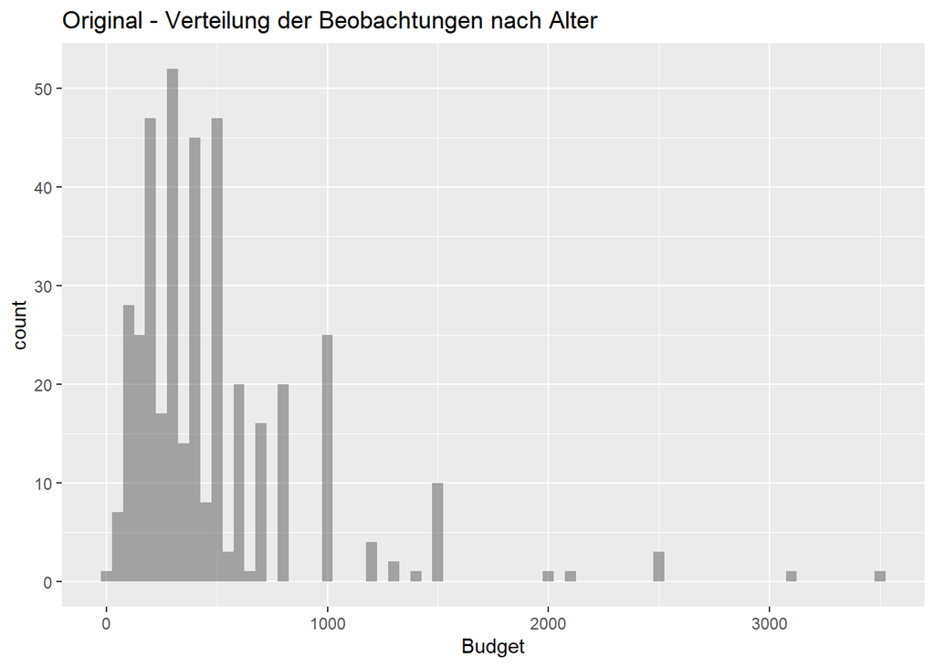

```r
gf_histogram(~ Budget, data = raw.training, binwidth = 50, center = 50, title = "Original - Verteilung der Beobachtungen nach Alter")
```

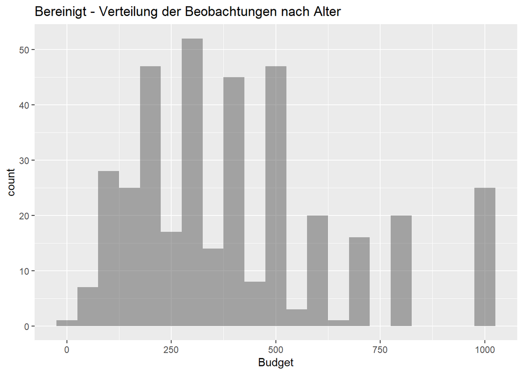

```r
gf_histogram(~ Budget, data = training, binwidth = 50, center = 50, title = "Bereinigt - Verteilung der Beobachtungen nach Alter")
```

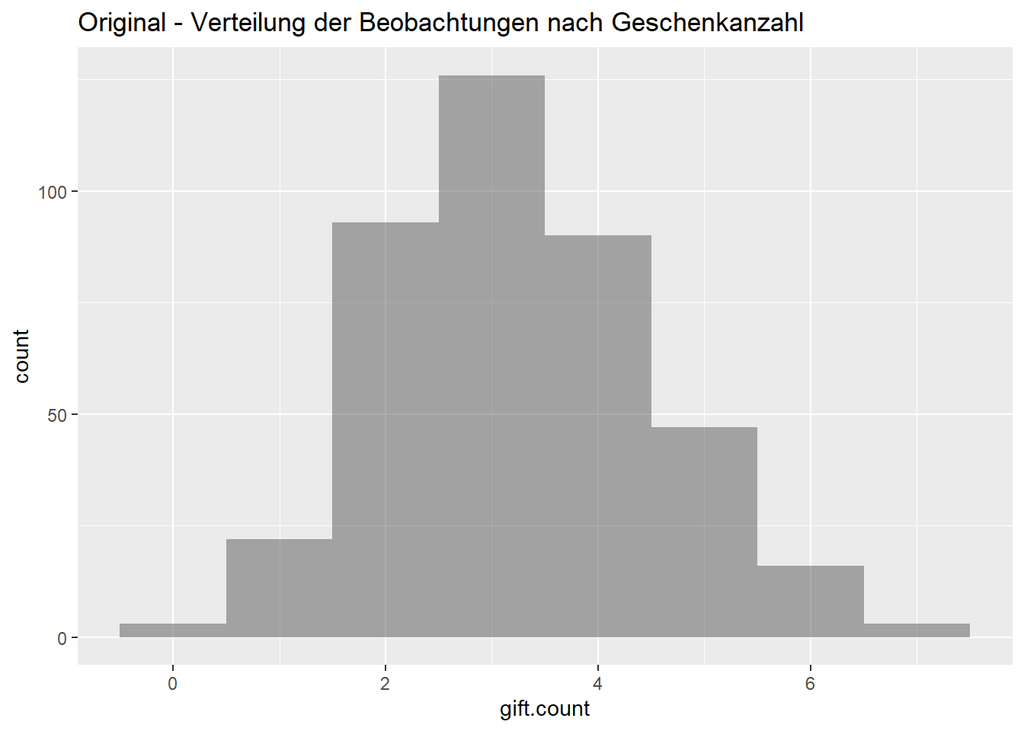

```r
gf_histogram(~ gift.count, data = raw.training, binwidth = 1, center = 1, title = "Original - Verteilung der Beobachtungen nach Geschenkanzahl")
```

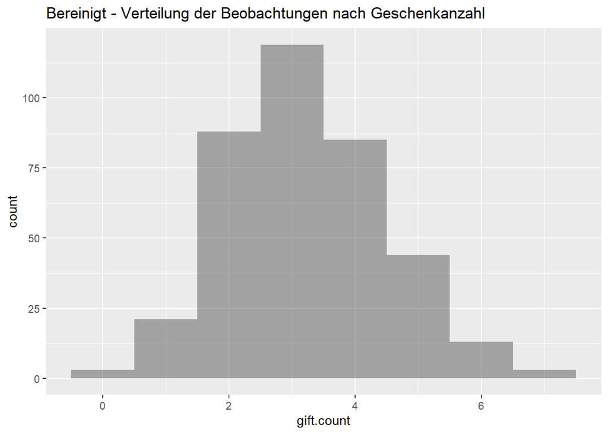

```r
gf_histogram(~ gift.count, data = training, binwidth = 1, center = 1, title = "Bereinigt - Verteilung der Beobachtungen nach Geschenkanzahl")
```